# irCLIP-RNP dataset to compare 1U/µL vs 0.02U/µL RNase I digestions

Luca Ducoli

This is the pipeline used to analyze the irCLIP-RNP datasets after digestion with two different RNase doses (1U/µL and 0.02U/µL), named here as “high”: 1U/µL and “low”: 0.02U/µL. Gel sections ranging from 70 to 350KDa (a.k.a “whole RNP zone”) were subjected to MS. The experiment was performed in HEK293T cells.

# 1. Prepare the dataset

```r
#Load the libraries
library(formatR)
library(DEP2)
library(tidyverse)
library(ggpubr)
library(Clipper)
library(viridis)
library(patchwork)
library(hrbrthemes)
library(igraph)
library(ggraph)
library(colormap)
library(UpSetR)
library(ggplot2)
library(arcdiagram)
library(pheatmap)
library(grid)
library(DESeq2)
library(data.table)
library(eulerr)
library(SuperExactTest)
```

In the first step, we prepared the dataset to create a SummarizedExperiment object starting from the proteinGroups.txt output file from MaxQuant.

```r
# Open proteinGroups.txt results from MaxQuant
data <- read.delim("~/Documents/Postdoc/PD_Projects/3_irCLIP-RNP/MS/RNase_HighLow_293T/0_Data/proteinGroups.txt")

# Remove RPL proteins
data <- data[-grep("RPL", data$Gene.names), ]

# Generate unique names and ids
unique_pg <- make_unique(data, name = "Gene.names", ids = "Protein.IDs")
unique_pg <- unique_pg %>%
    arrange(name)

# Get the LFQ intensity
ecols <- grep("LFQ.intensity.", colnames(unique_pg))

# Keep isoform with higher LFQ intensity
iso <- grep("\\.\\d+$", unique_pg$name)
rbp <- gsub("\\.1", "", c(unique_pg$name[iso]))

# Find original row name of the isoform with higher
# intensity
find_max_value <- function(rbp) {
    filtered_df <- unique_pg[unique_pg$name %like% rbp, grep("LFQ.intensity.",
        colnames(unique_pg))]
    filtered_df$rowSums <- rowSums(filtered_df[, grep("LFQ.intensity.",
        colnames(filtered_df))])
    max_value <- which.max(filtered_df$rowSums)
    rownames <- rownames(filtered_df)[-max_value]
    return(rownames)
}
max_iso <- c(unlist(lapply(rbp, find_max_value)))

# Remove low intensity isoforms
unique_pg <- unique_pg[!(rownames(unique_pg) %in% max_iso), ]

head(unique_pg, n = 2)
```

|  | Protein.IDs | Majority.protein.IDs | Peptide.counts..all. | Peptide.counts..razor.unique. | Peptide.counts..unique. | Protein.names | Gene.names | Fasta.headers | Number.of.proteins | Peptides | Razor...unique.peptides | Unique.peptides | Peptides.BZ10 | Peptides.BZ11 | Peptides.BZ12 | Peptides.BZ13 | Peptides.BZ14 | Peptides.BZ15 | Peptides.BZ16 | Peptides.BZ17 | Peptides.BZ18 | Peptides.BZ19 | Peptides.BZ20 | Peptides.BZ21 | Peptides.BZ6 | Peptides.BZ7 | Peptides.BZ8 | Peptides.BZ9 | Razor...unique.peptides.BZ10 | … |
| --- | --- | --- | --- | --- | --- | --- | --- | --- | --- | --- | --- | --- | --- | --- | --- | --- | --- | --- | --- | --- | --- | --- | --- | --- | --- | --- | --- | --- | --- | --- |
| 1 | Q8NE71;Q8NE71-2 | Q8NE71;Q8NE71-2 | 23;22 | 23;22 | 23;22 | ATP-binding cassette sub-family F member 1 | ABCF1 | sp\|Q8NE71\|ABCF1_HUMAN ATP-binding cassette sub-family F member 1 OS=Homo sapiens OX=9606 GN=ABCF1 PE=1 SV=2;sp\|Q8NE71-2\|ABCF1_HUMAN Isoform 2 of ATP-binding cassette sub-family F member 1 OS=Homo … | 2 | 23 | 23 | 23 | 14 | 21 | 16 | 16 | 16 | 14 | 0 | 1 | 0 | 0 | 0 | 0 | 14 | 0 | 0 | 15 | 14 | … |
| 2 | Q9UG63;Q9UG63-2 | Q9UG63;Q9UG63-2 | 3;3 | 3;3 | 3;3 | ATP-binding cassette sub-family F member 2 | ABCF2 | sp\|Q9UG63\|ABCF2_HUMAN ATP-binding cassette sub-family F member 2 OS=Homo sapiens OX=9606 GN=ABCF2 PE=1 SV=2;sp\|Q9UG63-2\|ABCF2_HUMAN Isoform 2 of ATP-binding cassette sub-family F member 2 OS=Homo … | 2 | 3 | 3 | 3 | 1 | 2 | 1 | 1 | 1 | 2 | 0 | 0 | 0 | 0 | 0 | 0 | 0 | 0 | 0 | 0 | 1 | … |

# 2. Create a SummarizedExperiment

We used the following design to create a SummarizedExperiment.

```r
#Load design matrix
design <- read.delim("~/Documents/Postdoc/PD_Projects/3_irCLIP-RNP/MS/RNase_HighLow_293T/0_Data/Design_matrix.txt")
design
```

| label | condition | rbp | replicate | crosslinking |
| --- | --- | --- | --- | --- |
| LFQ.intensity.BZ6 | HNRNPA2B1_noUV | HNRNPA2B1 | 1 | noUV |
| LFQ.intensity.BZ7 | HNRNPA2B1_high | HNRNPA2B1 | 1 | high |
| LFQ.intensity.BZ8 | HNRNPA2B1_high | HNRNPA2B1 | 2 | high |
| LFQ.intensity.BZ9 | HNRNPA2B1_low | HNRNPA2B1 | 1 | low |
| LFQ.intensity.BZ10 | HNRNPA2B1_low | HNRNPA2B1 | 2 | low |
| LFQ.intensity.BZ11 | HNRNPU_noUV | HNRNPU | 1 | noUV |
| LFQ.intensity.BZ12 | HNRNPU_high | HNRNPU | 1 | high |
| LFQ.intensity.BZ13 | HNRNPU_high | HNRNPU | 2 | high |
| LFQ.intensity.BZ14 | HNRNPU_low | HNRNPU | 1 | low |
| LFQ.intensity.BZ15 | HNRNPU_low | HNRNPU | 2 | low |

[output cut: 5 more lines]

```r
#Create a SummarizedExperiment
se <- make_se(unique_pg, columns = ecols, expdesign = design)

#Subset the SummarizedExperiment according to the proteins
HNRNPC_se <- se[,se$rbp == "HNRNPC" ]
HNRNPU_se <- se[,se$rbp == "HNRNPU" ]
HNRNPA2B1_se <- se[,se$rbp == "HNRNPA2B1" ]

#Remove noUV samples for comparing the two RNase doses
HNRNPC_se_flt2 <- HNRNPC_se[,HNRNPC_se$crosslinking != "noUV" ]
HNRNPU_se_flt2 <- HNRNPU_se[,HNRNPU_se$crosslinking != "noUV" ]
HNRNPA2B1_se_flt2 <- HNRNPA2B1_se[,HNRNPA2B1_se$crosslinking != "noUV" ]
```

# 3. Perform enrichment analysis using DEP

Here, we performed enrichment analysis by comparing the RNase high vs RNase low using the DEP2 R package (PMID: 37624922).

```r
set.seed(3)
#Function to calculate the differential expression
DEP_analysis <- function(se, a) {
  filt <- filter_se(se,thr = 0, filter_formula = ~ Reverse != '+' & Potential.contaminant !="+" & Peptides > 1 & Unique.peptides > 0)
  norm <- normalize_vsn(filt)
  imputed <- DEP2::impute(norm,fun = "QRILC")
  diff <- test_diff(imputed, type = "control", control = a, fdr.type = "BH")
  dep <- add_rejections(diff, alpha = 1, lfc = 0)
  results <- get_results(dep)
  return(list(se = se, filt = filt,
              norm = norm, imputed = imputed, diff = diff, dep = dep,
              results = results))
}

#Run DEP analysis
HNRNPC_se_DE <- DEP_analysis(se =  HNRNPC_se_flt2,a = "HNRNPC_low")
HNRNPU_se_DE <- DEP_analysis(se =  HNRNPU_se_flt2,a = "HNRNPU_low")
HNRNPA2B1_se_DE <- DEP_analysis(se =  HNRNPA2B1_se_flt2,a = "HNRNPA2B1_low")

head(HNRNPC_se_DE$results)
```

|  | name | ID | HNRNPC_high_vs_HNRNPC_low_p.val | HNRNPC_high_vs_HNRNPC_low_p.adj | significant | HNRNPC_high_vs_HNRNPC_low_significant | HNRNPC_high_vs_HNRNPC_low_ratio | HNRNPC_high_centered | HNRNPC_low_centered |
| --- | --- | --- | --- | --- | --- | --- | --- | --- | --- |
| 1 | DCD | P81605 | 0.53394372 | 0.571 | TRUE | TRUE | 1.230 | 0.617 | -0.617 |
| 2 | DDX1 | Q92499-3 | 0.06815325 | 0.103 | TRUE | TRUE | -3.370 | -1.690 | 1.690 |
| 3 | DDX17 | Q92841 | 0.37545198 | 0.421 | TRUE | TRUE | 0.220 | 0.110 | -0.110 |
| 4 | DDX3X | O00571-2 | 0.10961081 | 0.158 | TRUE | TRUE | 0.640 | 0.320 | -0.320 |
| 5 | DDX5 | P17844 | 0.16397844 | 0.210 | TRUE | TRUE | 0.608 | 0.304 | -0.304 |
| 6 | DHX9 | Q08211 | 0.18833307 | 0.234 | TRUE | TRUE | -0.512 | -0.256 | 0.256 |

```r
#Save the LFQ intensities
write.table(as.data.frame(HNRNPC_se_DE$dep@assays@data@listData), file = "~/Documents/Postdoc/PD_Projects/3_irCLIP-RNP/MS/RNase_HighLow_293T/2_DEP/HNRNPC_se_DE_LFQ_intensity.txt", row.names = TRUE, sep = "\t", quote = F)
write.table(as.data.frame(HNRNPU_se_DE$dep@assays@data@listData), file = "~/Documents/Postdoc/PD_Projects/3_irCLIP-RNP/MS/RNase_HighLow_293T/2_DEP/HNRNPU_se_DE_LFQ_intensity.txt", row.names = TRUE, sep = "\t", quote = F)
write.table(as.data.frame(HNRNPA2B1_se_DE$dep@assays@data@listData), file = "~/Documents/Postdoc/PD_Projects/3_irCLIP-RNP/MS/RNase_HighLow_293T/2_DEP/HNRNPA2B1_se_DE_LFQ_intensity.txt", row.names = TRUE, sep = "\t", quote = F)

write.table(HNRNPC_se_DE$results, file = "~/Documents/Postdoc/PD_Projects/3_irCLIP-RNP/MS/RNase_HighLow_293T/2_DEP/HNRNPC_se_norm_QRILC_res_LFQ_intensity.txt", row.names = FALSE, sep = "\t", quote = F)
write.table(HNRNPU_se_DE$results, file = "~/Documents/Postdoc/PD_Projects/3_irCLIP-RNP/MS/RNase_HighLow_293T/2_DEP/HNRNPU_se_norm_QRILC_res_LFQ_intensity.txt", row.names = FALSE, sep = "\t", quote = F)
write.table(HNRNPA2B1_se_DE$results, file = "~/Documents/Postdoc/PD_Projects/3_irCLIP-RNP/MS/RNase_HighLow_293T/2_DEP/HNRNPA2B1_se_norm_QRILC_res_LFQ_intensity.txt", row.names = FALSE, sep = "\t", quote = F)
```

Significant reduced proteins were selected as proteins having an FDR < 0.05 and a logFC vs RNase low (0.02U/µL) dose < 0.

# 4. Perform FDR analysis using Clipper

We used Clipper (PMID:34635147) function to compare noUV (1 replicate) and UVC samples (2 replicates for each RNase dose).

```r
#Impute data with noUV
HNRNPC_se_flt <- HNRNPC_se[rownames(HNRNPC_se_DE$filt)]
write.table(as.data.frame(HNRNPC_se@assays@data@listData), file = "~/Documents/Postdoc/PD_Projects/3_irCLIP-RNP/MS/RNase_HighLow_293T/2_DEP/HNRNPC_se_LFQ_intensity_raw.txt", row.names = TRUE, sep = "\t", quote = F)
HNRNPC_se_flt <- DEP2::impute(HNRNPC_se_flt,fun = "QRILC")
HNRNPU_se_flt <- HNRNPU_se[rownames(HNRNPU_se_DE$filt)]
write.table(as.data.frame(HNRNPU_se@assays@data@listData), file = "~/Documents/Postdoc/PD_Projects/3_irCLIP-RNP/MS/RNase_HighLow_293T/2_DEP/HNRNPU_se_LFQ_intensity_raw.txt", row.names = TRUE, sep = "\t", quote = F)
HNRNPU_se_flt <- DEP2::impute(HNRNPU_se_flt,fun = "QRILC")
HNRNPA2B1_se_flt <- HNRNPA2B1_se[rownames(HNRNPA2B1_se_DE$filt)]
write.table(as.data.frame(HNRNPA2B1_se@assays@data@listData), file = "~/Documents/Postdoc/PD_Projects/3_irCLIP-RNP/MS/RNase_HighLow_293T/2_DEP/HNRNPA2B1_se_LFQ_intensity_raw.txt", row.names = TRUE, sep = "\t", quote = F)
HNRNPA2B1_se_flt <- DEP2::impute(HNRNPA2B1_se_flt,fun = "QRILC")

#Prepare data for clipper
HNRNPC_data <- as.data.frame(HNRNPC_se_flt@assays@data@listData)
HNRNPU_data <- as.data.frame(HNRNPU_se_flt@assays@data@listData)
HNRNPA2B1_data <- as.data.frame(HNRNPA2B1_se_flt@assays@data@listData)

#Run Clipper on low and high samples
HNRNPC_clipper_high = Clipper(score.exp = as.matrix(HNRNPC_data[,c(2,3)]), score.back = as.matrix(HNRNPC_data[,-c(2,3,4,5)]), FDR = 0.1, analysis = "e")
HNRNPC_clipper_low = Clipper(score.exp = as.matrix(HNRNPC_data[,c(4,5)]), score.back = as.matrix(HNRNPC_data[,-c(2,3,4,5)]), FDR = 0.1, analysis = "e")

HNRNPU_clipper_high = Clipper(score.exp = as.matrix(HNRNPU_data[,c(2,3)]), score.back = as.matrix(HNRNPU_data[,-c(2,3,4,5)]), FDR = 0.1, analysis = "e")
HNRNPU_clipper_low = Clipper(score.exp = as.matrix(HNRNPU_data[,c(4,5)]), score.back = as.matrix(HNRNPU_data[,-c(2,3,4,5)]), FDR = 0.1, analysis = "e")

HNRNPA2B1_clipper_high = Clipper(score.exp = as.matrix(HNRNPA2B1_data[,c(2,3)]), score.back = as.matrix(HNRNPA2B1_data[,-c(2,3,4,5)]), FDR = 0.1, analysis = "e")
HNRNPA2B1_clipper_low = Clipper(score.exp = as.matrix(HNRNPA2B1_data[,c(4,5)]), score.back = as.matrix(HNRNPA2B1_data[,-c(2,3,4,5)]), FDR = 0.1, analysis = "e")

#Attach results to data
HNRNPC_data$FDR_high <- HNRNPC_clipper_high$q
HNRNPU_data$FDR_high <- HNRNPU_clipper_high$q
HNRNPA2B1_data$FDR_high <- HNRNPA2B1_clipper_high$q

HNRNPC_data$FDR_low <- HNRNPC_clipper_low$q
HNRNPU_data$FDR_low <- HNRNPU_clipper_low$q
HNRNPA2B1_data$FDR_low <- HNRNPA2B1_clipper_low$q

#Calculate logFC
HNRNPC_data$logFC_high <- rowMeans(HNRNPC_data[,c(2,3)])-HNRNPC_data$HNRNPC_noUV_1
HNRNPC_data$logFC_low <- rowMeans(HNRNPC_data[,c(4,5)])-HNRNPC_data$HNRNPC_noUV_1

HNRNPU_data$logFC_high <- rowMeans(HNRNPU_data[,c(2,3)])-HNRNPU_data$HNRNPU_noUV_1
HNRNPU_data$logFC_low <- rowMeans(HNRNPU_data[,c(4,5)])-HNRNPU_data$HNRNPU_noUV_1

HNRNPA2B1_data$logFC_high <- rowMeans(HNRNPA2B1_data[,c(2,3)])-HNRNPA2B1_data$HNRNPA2B1_noUV_1
HNRNPA2B1_data$logFC_low <- rowMeans(HNRNPA2B1_data[,c(4,5)])-HNRNPA2B1_data$HNRNPA2B1_noUV_1

head(HNRNPC_data)
```

|  | HNRNPC_noUV_1 | HNRNPC_high_1 | HNRNPC_high_2 | HNRNPC_low_1 | HNRNPC_low_2 | FDR_high | FDR_low | logFC_high | logFC_low |
| --- | --- | --- | --- | --- | --- | --- | --- | --- | --- |
| DCD | 23.22081 | 23.00590 | 22.68121 | 24.15777 | 18.66839 | 1.00000000 | 0.02222222 | -0.3772564 | -1.8077345 |
| DDX1 | 20.53089 | 18.51677 | 17.78069 | 21.02425 | 21.10534 | 1.00000000 | 0.02222222 | -2.3821578 | 0.5339063 |
| DDX17 | 12.26102 | 23.08323 | 22.96714 | 22.99967 | 23.18721 | 0.02439024 | 0.02222222 | 10.7641615 | 10.8324139 |
| DDX3X | 15.39217 | 19.04855 | 19.43683 | 19.86245 | 20.17217 | 0.02439024 | 0.02222222 | 3.8505197 | 4.6251393 |
| DDX5 | 13.12702 | 21.05768 | 20.41967 | 20.55309 | 20.28444 | 0.02439024 | 0.02222222 | 7.6116546 | 7.2917438 |
| DHX9 | 15.48094 | 21.39477 | 20.72251 | 21.82287 | 21.89360 | 0.02439024 | 0.02222222 | 5.5777032 | 6.3772984 |

```r
#Save the clipper results
write.table(HNRNPC_data, file = "~/Documents/Postdoc/PD_Projects/3_irCLIP-RNP/MS/RNase_HighLow_293T/2_DEP/HNRNPC_clipper_results.txt", row.names = TRUE, sep = "\t", quote = F)
write.table(HNRNPU_data, file = "~/Documents/Postdoc/PD_Projects/3_irCLIP-RNP/MS/RNase_HighLow_293T/2_DEP/HNRNPU_clipper_results.txt", row.names = TRUE, sep = "\t", quote = F)
write.table(HNRNPA2B1_data, file = "~/Documents/Postdoc/PD_Projects/3_irCLIP-RNP/MS/RNase_HighLow_293T/2_DEP/HNRNPA2B1_clipper_results.txt", row.names = TRUE, sep = "\t", quote = F)
```

# 5. Visualization of the results

For the visualization, we first filter the DEP results for UVC-enriched proteins (a.k.a RDAPs). Only proteins with an FDR < 0.1 and a FC vs noUV > 3 in at least one RNase condition were categorized as RDAPs.

```r
#Store DEP results
HNRNPC <- HNRNPC_se_DE$results
HNRNPU <- HNRNPU_se_DE$results
HNRNPA2B1 <- HNRNPA2B1_se_DE$results

#Get the significant UVC-enriched proteins
HNRNPC_data_sub <- subset(HNRNPC_data, (HNRNPC_data$logFC_low > log2(3) & HNRNPC_data$FDR_low < 0.1) | (HNRNPC_data$logFC_high > log2(3) & HNRNPC_data$FDR_high < 0.1))
HNRNPU_data_sub <- subset(HNRNPU_data, (HNRNPU_data$logFC_low > log2(3) & HNRNPU_data$FDR_low < 0.1) | (HNRNPU_data$logFC_high > log2(3) & HNRNPU_data$FDR_high < 0.1))
HNRNPA2B1_data_sub <- subset(HNRNPA2B1_data, (HNRNPA2B1_data$logFC_low > log2(3) & HNRNPA2B1_data$FDR_low < 0.1) | (HNRNPA2B1_data$logFC_high > log2(3) & HNRNPA2B1_data$FDR_high < 0.1))

#Keep only UVC-enriched proteins
HNRNPC <- subset(HNRNPC, HNRNPC$name %in% rownames(HNRNPC_data_sub))
HNRNPU <- subset(HNRNPU, HNRNPU$name %in% rownames(HNRNPU_data_sub))
HNRNPA2B1 <- subset(HNRNPA2B1, HNRNPA2B1$name %in% rownames(HNRNPA2B1_data_sub))

#Determine the significant proteins
HNRNPC$sign <- HNRNPC$HNRNPC_high_vs_HNRNPC_low_p.adj < 0.05
HNRNPU$sign <- HNRNPU$HNRNPU_high_vs_HNRNPU_low_p.adj < 0.05
HNRNPA2B1$sign <- HNRNPA2B1$HNRNPA2B1_high_vs_HNRNPA2B1_low_p.adj < 0.05

head(HNRNPC, n = 2)
```

|  | name | ID | HNRNPC_high_vs_HNRNPC_low_p.val | HNRNPC_high_vs_HNRNPC_low_p.adj | significant | HNRNPC_high_vs_HNRNPC_low_significant | HNRNPC_high_vs_HNRNPC_low_ratio | HNRNPC_high_centered | HNRNPC_low_centered | sign |
| --- | --- | --- | --- | --- | --- | --- | --- | --- | --- | --- |
| 3 | DDX17 | Q92841 | 0.3754520 | 0.421 | TRUE | TRUE | 0.22 | 0.11 | -0.11 | FALSE |
| 4 | DDX3X | O00571-2 | 0.1096108 | 0.158 | TRUE | TRUE | 0.64 | 0.32 | -0.32 | FALSE |

## Rank plot of intensities

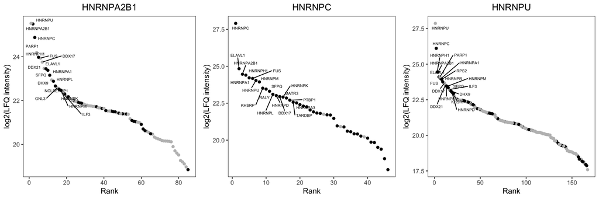

```r
#Get the ranking of the proteins
HNRNPC_norm <- as.data.frame(HNRNPC_se_DE$dep@assays@data@listData)
HNRNPC_norm$name <- rownames(HNRNPC_norm)
HNRNPC_norm$low_avg <- rowMeans(HNRNPC_norm[,3:4])
HNRNPC_norm$UVC <- HNRNPC_norm$name %in% HNRNPC$name

HNRNPU_norm <- as.data.frame(HNRNPU_se_DE$dep@assays@data@listData)
HNRNPU_norm$name <- rownames(HNRNPU_norm)
HNRNPU_norm$low_avg <- rowMeans(HNRNPU_norm[,3:4])
HNRNPU_norm$UVC <- HNRNPU_norm$name %in% HNRNPU$name

HNRNPA2B1_norm <- as.data.frame(HNRNPA2B1_se_DE$dep@assays@data@listData)
HNRNPA2B1_norm$name <- rownames(HNRNPA2B1_norm)
HNRNPA2B1_norm$low_avg <- rowMeans(HNRNPA2B1_norm[,3:4])
HNRNPA2B1_norm$UVC <- HNRNPA2B1_norm$name %in% HNRNPA2B1$name

HNRNPC_norm$Rank = rank(-HNRNPC_norm$low_avg)
HNRNPU_norm$Rank = rank(-HNRNPU_norm$low_avg)
HNRNPA2B1_norm$Rank = rank(-HNRNPA2B1_norm$low_avg)

options(ggrepel.max.overlaps = Inf)

HNRNPC_plot <- ggplot(HNRNPC_norm, aes(x=Rank, y=low_avg, label = name)) +
  geom_point(aes(col = UVC)) +
  scale_color_manual(values = c(`TRUE` = "black", `FALSE` = "grey")) +
  ggrepel::geom_text_repel(data = subset(HNRNPC_norm, Rank < 20), size = 2) +
    theme_bw() +
  ggtitle("HNRNPC") +
  theme(legend.position = "none", panel.grid.major = element_blank(),
        panel.grid.minor = element_blank(),
        panel.background = element_blank(),
        axis.line = element_blank(),
        plot.title = element_text(hjust = 0.5)) +
  xlab("Rank") +
  ylab("log2(LFQ intensity)")

HNRNPU_plot <- ggplot(HNRNPU_norm, aes(x=Rank, y=low_avg, label = name)) +
  geom_point(aes(col = UVC)) +
  scale_color_manual(values = c(`TRUE` = "black", `FALSE` = "grey")) +
  ggrepel::geom_text_repel(data = subset(HNRNPU_norm, Rank < 20), size = 2) +
    theme_bw() +
  ggtitle("HNRNPU") +
  theme(legend.position = "none", panel.grid.major = element_blank(),
        panel.grid.minor = element_blank(),
        panel.background = element_blank(),
        axis.line = element_blank(),
        plot.title = element_text(hjust = 0.5)) +
  xlab("Rank") +
  ylab("log2(LFQ intensity)")

HNRNPA2B1_plot <- ggplot(HNRNPA2B1_norm, aes(x=Rank, y=low_avg, label = name)) +
  geom_point(aes(col = UVC)) +
  scale_color_manual(values = c(`TRUE` = "black", `FALSE` = "grey")) +
  ggrepel::geom_text_repel(data = subset(HNRNPA2B1_norm, Rank < 20), size = 2) +
    theme_bw() +
  ggtitle("HNRNPA2B1") +
  theme(legend.position = "none", panel.grid.major = element_blank(),
        panel.grid.minor = element_blank(),
        panel.background = element_blank(),
        axis.line = element_blank(),
        plot.title = element_text(hjust = 0.5)) +
  xlab("Rank") +
  ylab("log2(LFQ intensity)")


ggarrange(HNRNPA2B1_plot, HNRNPC_plot, HNRNPU_plot, ncol = 3)
```

```r
#Save the plot as pdf
pdf("~/Documents/Postdoc/PD_Projects/3_irCLIP-RNP/MS/RNase_HighLow_293T/3_DEP_visualization/Rank_plot.pdf", height = 4, width = 12)
ggarrange(HNRNPA2B1_plot, HNRNPC_plot, HNRNPU_plot, ncol = 3)
dev.off()
```

## Volcano plots

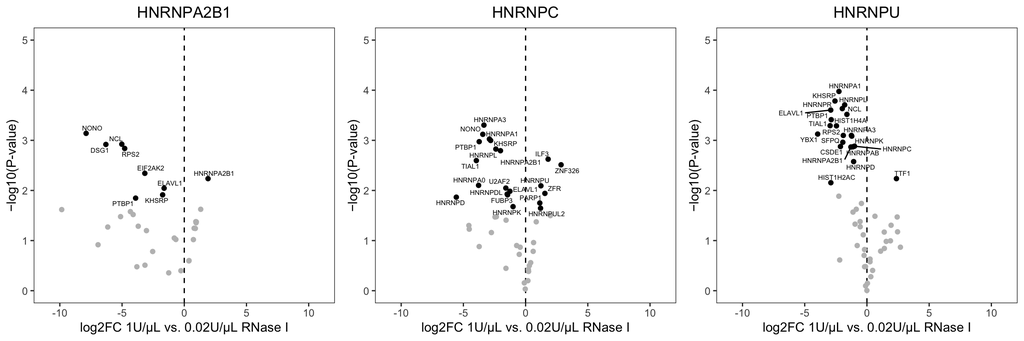

```r
#Create a volcano plot
HNRNPC.ggplot <- ggplot(data=HNRNPC, aes(x=HNRNPC_high_vs_HNRNPC_low_ratio, y=-log10(HNRNPC_high_vs_HNRNPC_low_p.val))) + geom_vline(xintercept = 0, linetype = "dashed") +
  geom_point(aes(col = sign)) +
  scale_color_manual(values = c(`TRUE` = "black", `FALSE` = "grey")) +
    ggrepel::geom_text_repel(data = filter(HNRNPC, sign), aes(label = name), size = 2, box.padding = unit(0.1, "lines"), point.padding = unit(0.1, "lines"), segment.size = 0.5,max.overlaps = Inf) +
  theme_bw() +
  ggtitle("HNRNPC") +
  theme(legend.position = "none", panel.grid.major = element_blank(),
        panel.grid.minor = element_blank(),
        panel.background = element_blank(),
        axis.line = element_blank(),
        plot.title = element_text(hjust = 0.5)) +
  xlab("log2FC 1U/µL vs. 0.02U/µL RNase I") +
  ylab("−log10(P-value)") +
  xlim(-11, 11) +
  ylim(0, 5)

HNRNPU.ggplot <- ggplot(data=HNRNPU, aes(x=HNRNPU_high_vs_HNRNPU_low_ratio, y=-log10(HNRNPU_high_vs_HNRNPU_low_p.val))) + geom_vline(xintercept = 0, linetype = "dashed") +
  geom_point(aes(col = sign)) +
  scale_color_manual(values = c(`TRUE` = "black", `FALSE` = "grey")) +
    ggrepel::geom_text_repel(data = filter(HNRNPU, sign), aes(label = name), size = 2, box.padding = unit(0.1, "lines"), point.padding = unit(0.1, "lines"), segment.size = 0.5,max.overlaps = Inf) +
  theme_bw() +
  ggtitle("HNRNPU") +
  theme(legend.position = "none", panel.grid.major = element_blank(),
        panel.grid.minor = element_blank(),
        panel.background = element_blank(),
        axis.line = element_blank(),
        plot.title = element_text(hjust = 0.5)) +
  xlab("log2FC 1U/µL vs. 0.02U/µL RNase I") +
  ylab("−log10(P-value)") +
  xlim(-11, 11) +
  ylim(0, 5)

HNRNPA2B1.ggplot <- ggplot(data=HNRNPA2B1, aes(x=HNRNPA2B1_high_vs_HNRNPA2B1_low_ratio, y=-log10(HNRNPA2B1_high_vs_HNRNPA2B1_low_p.val))) + geom_vline(xintercept = 0, linetype = "dashed") +
  geom_point(aes(col = sign)) +
  scale_color_manual(values = c(`TRUE` = "black", `FALSE` = "grey")) +
  ggrepel::geom_text_repel(data = filter(HNRNPA2B1, sign), aes(label = name), size = 2, box.padding = unit(0.1, "lines"), point.padding = unit(0.1, "lines"), segment.size = 0.5,max.overlaps = Inf) +
  theme_bw() +
  ggtitle("HNRNPA2B1") +
  theme(legend.position = "none", panel.grid.major = element_blank(),
        panel.grid.minor = element_blank(),
        panel.background = element_blank(),
        axis.line = element_blank(),
        plot.title = element_text(hjust = 0.5)) +
  xlab("log2FC 1U/µL vs. 0.02U/µL RNase I") +
  ylab("−log10(P-value)") +
  xlim(-11, 11) +
  ylim(0, 5)

ggarrange(HNRNPA2B1.ggplot, HNRNPC.ggplot, HNRNPU.ggplot, ncol = 3)
```

```r
#Save the plot as pdf
pdf("~/Documents/Postdoc/PD_Projects/3_irCLIP-RNP/MS/RNase_HighLow_293T/3_DEP_visualization/Volcano_plot.pdf", height = 4, width = 12)
ggarrange(HNRNPA2B1.ggplot, HNRNPC.ggplot, HNRNPU.ggplot, ncol = 3)
dev.off()
```

## Upset plot

Here, we compared the overlap of the RDAPs with significant reduction after 1U/µL between the RBP tested using upset plot.

```r
#Subset significant proteins
HNRNPC_flt <- subset(HNRNPC, HNRNPC_high_vs_HNRNPC_low_p.adj < 0.05 & HNRNPC_high_vs_HNRNPC_low_ratio < 0)
HNRNPA2B1_flt <- subset(HNRNPA2B1, HNRNPA2B1_high_vs_HNRNPA2B1_low_p.adj < 0.05 & HNRNPA2B1_high_vs_HNRNPA2B1_low_ratio < 0)
HNRNPU_flt <- subset(HNRNPU, HNRNPU_high_vs_HNRNPU_low_p.adj < 0.05 & HNRNPU_high_vs_HNRNPU_low_ratio < 0)

#Make upset plot of detected proteins in noUV samples
lt.tsk = list(HNRNPC = HNRNPC_flt$name,
              HNRNPU = HNRNPU_flt$name,
              HNRNPA2B1 = HNRNPA2B1_flt$name)

upsetPlot <- upset(fromList(lt.tsk),
      sets = c("HNRNPU","HNRNPC","HNRNPA2B1"),
      mb.ratio = c(0.8, 0.2),
      number.angles = 0,
      text.scale = 1,
      point.size = 3,
      line.size = 1,
      keep.order = TRUE,
      # empty.intersections = "on"
      # queries = list(list(query = intersects, params = list("tss.total"), color = "red", active = T))
)
```

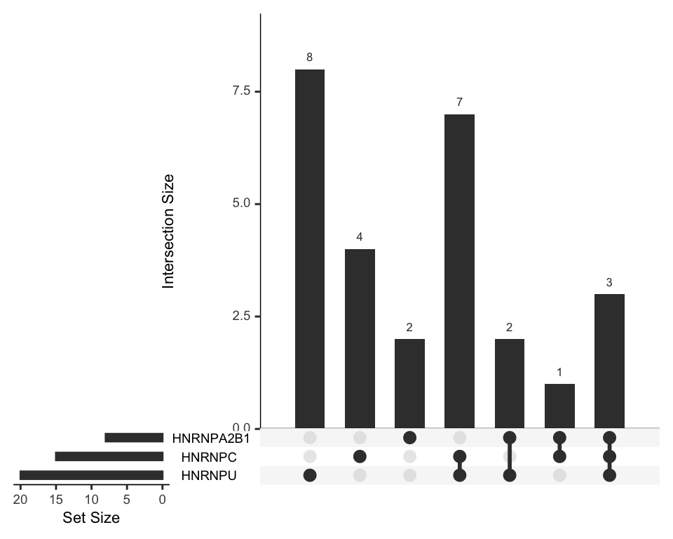

```r
upsetPlot
```

```r
#Save the upsetplot as pdf
pdf("~/Documents/Postdoc/PD_Projects/3_irCLIP-RNP/MS/RNase_HighLow_293T/3_DEP_visualization/Upsetplot_signprot.pdf", width = 3.5, height = 5)
upsetPlot
dev.off()
```

## Arc diagram

We then used these information to generated a binary table of the interaction that we will use for generating the arc diagram.

```r
#Function to create the binary table
fromList <- function (input) {
  elements <- unique(unlist(input))
  data <- unlist(lapply(input, function(x) {
    x <- as.vector(match(elements, x))
  }))
  data[is.na(data)] <- as.integer(0)
  data[data != 0] <- as.integer(1)
  data <- data.frame(matrix(data, ncol = length(input), byrow = F))
  data <- data[which(rowSums(data) != 0), ]
  names(data) <- names(input)
  row.names(data) <- elements
  return(data)
}

#Binary table with colnames:
sign.proteins <- fromList(lt.tsk)
write.table(sign.proteins, file = "~/Documents/Postdoc/PD_Projects/3_irCLIP-RNP/MS/RNase_HighLow_293T/3_DEP_visualization/Upsetplot_signprot.txt", row.names = TRUE, sep = "\t", quote = F)

head(sign.proteins)
```

|  | HNRNPC | HNRNPU | HNRNPA2B1 |
| --- | --- | --- | --- |
| ELAVL1 | 1 | 1 | 1 |
| FUBP3 | 1 | 0 | 0 |
| HNRNPA0 | 1 | 0 | 0 |
| HNRNPA1 | 1 | 1 | 0 |
| HNRNPA2B1 | 1 | 1 | 0 |
| HNRNPA3 | 1 | 1 | 0 |

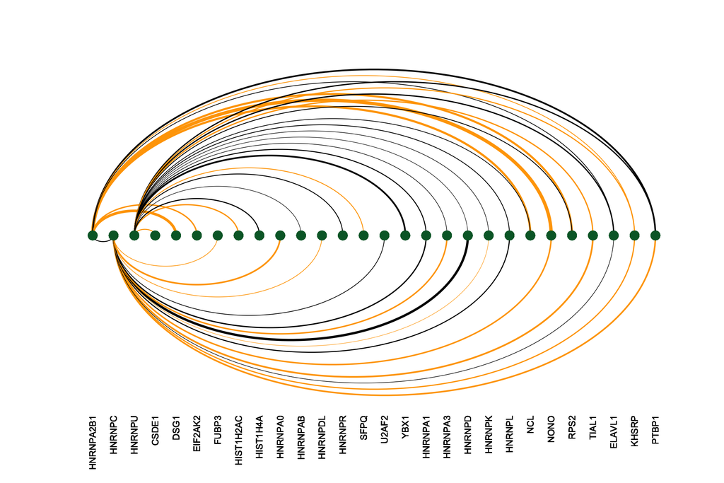

```r
#Prepare data
data_int <- data.frame(to = c(HNRNPC_flt$name, HNRNPU_flt$name, HNRNPA2B1_flt$name),
                       ratio = c(HNRNPC_flt$HNRNPC_high_vs_HNRNPC_low_ratio, HNRNPU_flt$HNRNPU_high_vs_HNRNPU_low_ratio, HNRNPA2B1_flt$HNRNPA2B1_high_vs_HNRNPA2B1_low_ratio))
data_int$from <- c(rep("HNRNPC", length(HNRNPC_flt$name)), rep("HNRNPU", length(HNRNPU_flt$name)), rep("HNRNPA2B1", length(HNRNPA2B1_flt$name)))
connect <- data_int[,c(3,1:2)]
connect <- connect %>% group_by(from) %>% arrange(ratio, .by_group=TRUE)

mygraph <- graph_from_data_frame( connect, directed = FALSE )

#Number of connection per RBP
c( as.character(connect$from), as.character(connect$to)) %>%
  as.tibble() %>%
  group_by(value) %>%
  summarize(n=n()) -> coauth
colnames(coauth) <- c("name", "n")

#Add grouping
coauth2 <- coauth[order(coauth$n, decreasing = TRUE),]
coauth2$grp <- c( rep(1, 3), rep( 4 , length(coauth2$n[coauth2$n == 3])), rep( 3 , length(coauth2$n[coauth2$n == 2])), rep( 2 , length(coauth2$n[coauth2$n == 1])))
coauth3 <- coauth2[order(coauth2$grp, decreasing = FALSE),]

#Generate a arcplot compatible object
star_edges = get.edgelist(mygraph)

#Load BioGRID interactions
biogrid <- read.delim("~/Documents/Postdoc/PD_Projects/3_irCLIP-RNP/MS/RNase_HighLow_293T/0_Data/BIOGRID/RBP_biogrid_interactors.txt",sep="\t", header=TRUE)
biogrid <- data.frame("a" = biogrid$Official.Symbol.Interactor.A, "b" = biogrid$Official.Symbol.Interactor.B)

#Compare the signifcant proteins to BioGrid annotation
hnC <- biogrid == "HNRNPC"
hnC <- data.frame("a"=biogrid$a,"b"=biogrid$b,"c"=paste(hnC[,1],hnC[,2], sep="_"))
hnC.1 <- subset(hnC, c == "TRUE_FALSE")
hnC.2 <- subset(hnC, c == "FALSE_TRUE")
hnC <- rbind(hnC.1,hnC.2)
hnC.a <- HNRNPC_flt$name %in% hnC$a
hnC.b <- HNRNPC_flt$name %in% hnC$b
hnC.int <- data.frame("gene" = HNRNPC_flt$name,"biogrid" = paste(hnC.a,hnC.b, sep = "_"))
hnC.int$rbp <- "HNRNPC"

hna2b1 <- biogrid == "HNRNPA2B1"
hna2b1 <- data.frame("a"=biogrid$a,"b"=biogrid$b,"c"=paste(hna2b1[,1],hna2b1[,2], sep="_"))
hna2b1.1 <- subset(hna2b1, c == "TRUE_FALSE")
hna2b1.2 <- subset(hna2b1, c == "FALSE_TRUE")
hna2b1 <- rbind(hna2b1.1,hna2b1.2)
hna2b1.a <- HNRNPA2B1_flt$name %in% hna2b1$a
hna2b1.b <- HNRNPA2B1_flt$name %in% hna2b1$b
hna2b1.int <- data.frame("gene" = HNRNPA2B1_flt$name,"biogrid" = paste(hna2b1.a,hna2b1.b, sep = "_"))
hna2b1.int$rbp <- "HNRNPA2B1"

hnU <- biogrid == "HNRNPU"
hnU <- data.frame("a"=biogrid$a,"b"=biogrid$b,"c"=paste(hnU[,1],hnU[,2], sep="_"))
hnU.1 <- subset(hnU, c == "TRUE_FALSE")
hnU.2 <- subset(hnU, c == "FALSE_TRUE")
hnU <- rbind(hnU.1,hnU.2)
hnU.a <- HNRNPU_flt$name %in% hnU$a
hnU.b <- HNRNPU_flt$name %in% hnU$b
hnU.int <- data.frame("gene" = HNRNPU_flt$name,"biogrid" = paste(hnU.a,hnU.b, sep = "_"))
hnU.int$rbp <- "HNRNPU"

#Combine the BioGRID results and prepare data for arcplot
all <- rbind(hnC.int,hna2b1.int,hnU.int)
write.table(all, file = "~/Documents/Postdoc/PD_Projects/3_irCLIP-RNP/MS/RNase_HighLow_293T/3_DEP_visualization/RNaseHL_BioGRID_interactions.txt", sep = "\t", row.names = FALSE, quote = F)

all$int <- paste(all$gene, all$rbp, sep = "_")
edges <- as.data.frame(star_edges)
edges$int <- paste(edges$V2, edges$V1, sep = "_")
all$int[grep("HNRNPA2B1_HNRNPC", all$int)] <- "HNRNPC_HNRNPA2B1"

idx <- match(all$int, edges$int)

all <- all[match(edges$int, all$int),]
all$color <- ifelse(all$biogrid == "FALSE_FALSE", "orange", "black")

#Do the arcplot
arcplot(star_edges, show.nodes = TRUE, show.labels = TRUE, ordering=coauth3$name[c(3,2,1,4:length(coauth3$name))],
        lwd.arcs=(connect$ratio*-1)/1.5, col.arcs=all$color,
        col.nodes = "#006633", cex.nodes=2, line=-0.5,col.labels = "black", ylim = c(-0.5,0.5), above = c(1:length(HNRNPA2B1_flt$name),(length(HNRNPA2B1_flt$name)+length(HNRNPC_flt$name)+1):length(star_edges[,1])))
```

Nodes: significant proteins; edges: significant reduced association with bait; edge width: logFC after DEP analysis; orange edge: novel putative associations.

```r
#Save the arc plot as PDF
pdf("~/Documents/Postdoc/PD_Projects/3_irCLIP-RNP/MS/RNase_HighLow_293T/3_DEP_visualization/Arcplot_signprot.pdf", width = 10, height = 5)
arcplot(star_edges, show.nodes = TRUE, show.labels = TRUE, ordering=coauth3$name[c(1,3,2,4:length(coauth3$name))],
        lwd.arcs=(connect$ratio*-1)/1.5, col.arcs=all$color,
        col.nodes = "#006633", cex.nodes=2, line=-0.5,col.labels = "black", ylim = c(-0.5,0.5), above = c(1:length(HNRNPA2B1_flt$name),(length(HNRNPA2B1_flt$name)+length(HNRNPC_flt$name)+1):length(star_edges[,1])))
dev.off()
```

## Heatmap

We also generated heatmap of imputed LFQ intensities for the RDAPs significantly reduced in at least one RBP tested.

```r
#Load results from imputed LFQ intensities used in DEP analysis
HNRNPC_LFQ <- as.data.frame(HNRNPC_se_DE$dep@assays@data@listData)
HNRNPU_LFQ <- as.data.frame(HNRNPU_se_DE$dep@assays@data@listData)
HNRNPA2B1_LFQ <- as.data.frame(HNRNPA2B1_se_DE$dep@assays@data@listData)

head(HNRNPC_LFQ)
```

|  | HNRNPC_high_1 | HNRNPC_high_2 | HNRNPC_low_1 | HNRNPC_low_2 |
| --- | --- | --- | --- | --- |
| DCD | 23.10995 | 22.86497 | 24.10267 | 19.40497 |
| DDX1 | 19.23464 | 15.86573 | 20.96915 | 20.87263 |
| DDX17 | 23.18728 | 23.15090 | 22.94457 | 22.95450 |
| DDX3X | 19.15259 | 19.62059 | 18.60218 | 18.89130 |
| DDX5 | 21.16173 | 20.60343 | 20.49799 | 20.05173 |
| DHX9 | 21.49882 | 20.90627 | 21.76777 | 21.66089 |

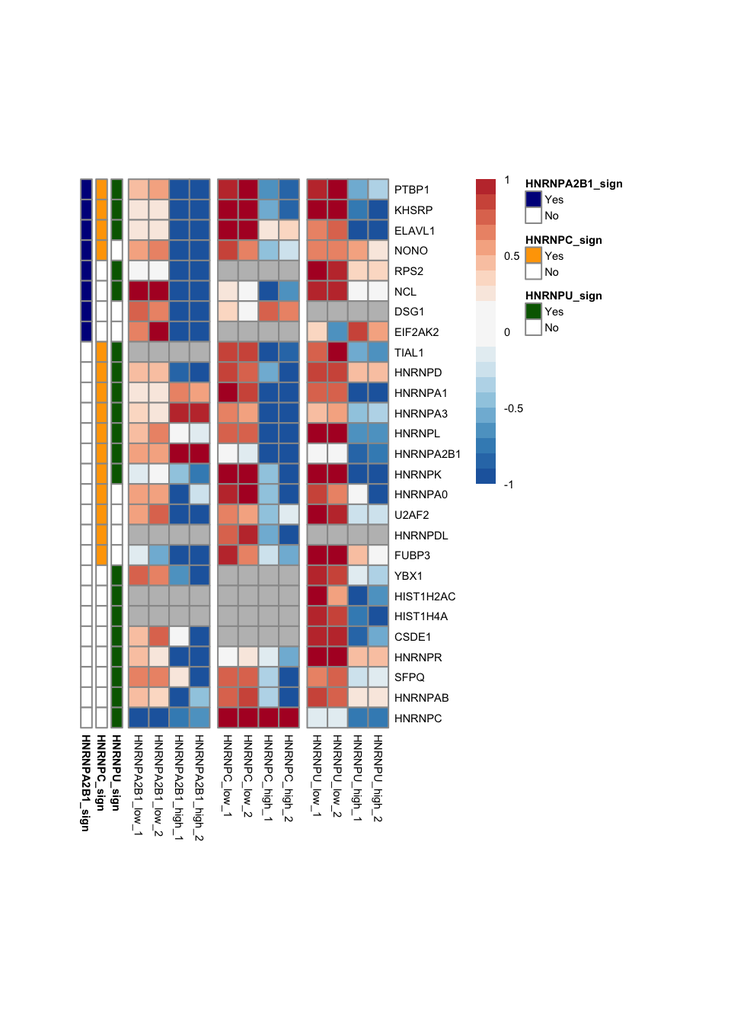

```r
#Get the significant proteins
sign_prot <- unique(c(HNRNPC_flt$name, HNRNPU_flt$name, HNRNPA2B1_flt$name))

rbp_fc <- merge(HNRNPC_flt[,c(1,7)], HNRNPU_flt[,c(1,7)], by = "name", all.x =TRUE, all.y = TRUE)
rbp_fc <- merge(rbp_fc, HNRNPA2B1_flt[,c(1,7)], by = "name", all.x =TRUE, all.y = TRUE)
rbp_fc <- rbp_fc %>% replace(is.na(.), 0)
rbp_fc$avglogfc <- rowMeans(rbp_fc[,2:4])


#Merge the LFQ intensities of RBP tested
all.LFQ <- merge(HNRNPA2B1_LFQ[,c(3,4,1,2)], HNRNPC_LFQ[,c(3,4,1,2)], by = "row.names", all = TRUE)
rownames(all.LFQ) <- all.LFQ$Row.names
all.LFQ <- merge(all.LFQ[-1], HNRNPU_LFQ[,c(3,4,1,2)], by = "row.names", all = TRUE)
rownames(all.LFQ) <- all.LFQ$Row.names
all.LFQ <- all.LFQ[-1]
all.LFQ <- all.LFQ[sign_prot,]

#Color scale to be used in the pheatmap
my.breaks <- c(seq(-1, -0.01, by=0.1), seq(0.1, 1, by=0.1))
my.colors <- c(colorRampPalette(colors = c("#2166AC", "#4393C3", "#92C5DE", "#D1E5F0", "#F7F7F7"))(length(my.breaks)/2), colorRampPalette(colors = c("#F7F7F7", "#FDDBC7", "#F4A582", "#D6604D", "#B2182B"))(length(my.breaks)/2))

#Annotation about significance
annotation <- as.data.frame(sign.proteins)
annotation$name <- rownames(annotation)
annotation <- merge(annotation, rbp_fc[,c(1,5)], by = "name")
rownames(annotation) <- annotation$name
annotation <- annotation[,c(3,2,4,5)]
annotation <- annotation %>% arrange(-HNRNPA2B1, -HNRNPC, -HNRNPU, avglogfc)
annotation[annotation == 1] <- "Yes"
annotation[annotation == 0] <- "No"
annotation$HNRNPU <- as.factor(annotation$HNRNPU)
annotation$HNRNPC <- as.factor(annotation$HNRNPC)
annotation$HNRNPA2B1 <- as.factor(annotation$HNRNPA2B1)
annotation <- annotation[,-c(4)]
colnames(annotation) <- c("HNRNPU_sign", "HNRNPC_sign", "HNRNPA2B1_sign")

ann_colors = list(HNRNPU_sign = c("Yes"="darkgreen", "No"="white"), HNRNPC_sign = c("Yes"="orange", "No"="white"), HNRNPA2B1_sign = c("Yes"="darkblue", "No"="white"))

all <- all.LFQ[match(rownames(annotation), rownames(all.LFQ)),]

#Generate the heatmap
pheatmap <- pheatmap(
  mat               = all,
  annotation_row = annotation,
  annotation_colors = ann_colors,
  cellheight=10,
  cellwidth = 10,
  na_col = "grey",
  color = my.colors,
  breaks = my.breaks,
  show_colnames     = TRUE,
  show_rownames     = TRUE,
  drop_levels       = TRUE,
  fontsize          = 5.5,
  cluster_rows      = FALSE,
  cluster_cols      = FALSE,
  scale             = "row",
  gaps_col = c(4,8)
)
```

```r
#Save the heatmap
pheatmap <- pheatmap(
  mat               = all,
  annotation_row = annotation,
  annotation_colors = ann_colors,
  cellheight=5,
  cellwidth = 5,
  na_col = "grey",
  color = my.colors,
  breaks = my.breaks,
  show_colnames     = TRUE,
  show_rownames     = TRUE,
  drop_levels       = TRUE,
  fontsize          = 5.5,
  cluster_rows      = FALSE,
  cluster_cols      = FALSE,
  scale             = "row",
  gaps_col = c(4,8),
  filename = "~/Documents/Postdoc/PD_Projects/3_irCLIP-RNP/MS/RNase_HighLow_293T/3_DEP_visualization/all_heatmap_LFQ.pdf",
  width = 5,
  height = 5
)
```

# 6. Integration of species-mixing irCLIP-RNP

We analyze the proportion of mouse and human peptides mapped to HNRNPC and HNRNPA2B1 RDAPs in the reciprocal species-mixing irCLIP-RNP datasets.

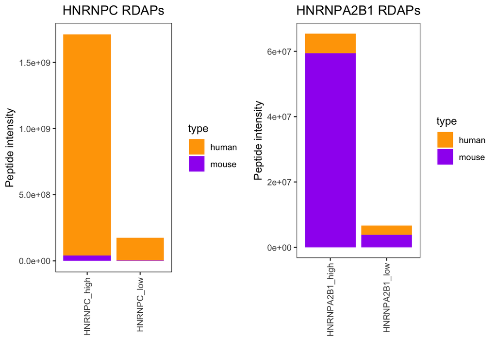

```r
pe <- readRDS("~/Documents/Postdoc/PD_Projects/3_irCLIP-RNP/MS/irCLIP-RNP_control/1_Species_mixing/Speciesmixing_summarized_exp.rds")
#Prepare data.frame
unique_pep <- 2^assay(pe[[2]])
unique_pep <- as.data.frame(unique_pep)
rownames(unique_pep) <- pe[[2]]@elementMetadata$name

#Average between samples
unique_pep$HNRNPC_low <- rowMeans(unique_pep[c(1,3)])
unique_pep$HNRNPC_high <- rowMeans(unique_pep[c(2,4)])
unique_pep$HNRNPA2B1_low <- rowMeans(unique_pep[c(5,7)])
unique_pep$HNRNPA2B1_high <- rowMeans(unique_pep[c(6,8)])
unique_pep$gene <-  factor(sapply(strsplit(rownames(unique_pep), "_"), function(x) x[1]))
unique_pep$gene_uppercase <- toupper(unique_pep$gene)

#Save the clipper results
HNRNPC_RDAP <- HNRNPC_data
HNRNPA2B1_RDAP <- HNRNPA2B1_data

#Get the significant UVC-enriched proteins
HNRNPC_data_sub <- subset(HNRNPC_RDAP, (HNRNPC_RDAP$logFC_low > log2(3) & HNRNPC_RDAP$FDR_low < 0.1) | (HNRNPC_RDAP$logFC_high > log2(3) & HNRNPC_RDAP$FDR_high < 0.1))
HNRNPA2B1_data_sub <- subset(HNRNPA2B1_RDAP, (HNRNPA2B1_RDAP$logFC_low > log2(3) & HNRNPA2B1_RDAP$FDR_low < 0.1) | (HNRNPA2B1_RDAP$logFC_high > log2(3) & HNRNPA2B1_RDAP$FDR_high < 0.1))

HNRNPC_pep <- subset(unique_pep, gene_uppercase %in% rownames(HNRNPC_data_sub))
HNRNPA2B1_pep <- subset(unique_pep, gene_uppercase %in% rownames(HNRNPA2B1_data_sub))

#Subset mouse unique peptides
HNRNPC_mouse_unique_pep <- HNRNPC_pep[grepl("[a-z]", rownames(HNRNPC_pep)), ]
HNRNPA2B1_mouse_unique_pep <- HNRNPA2B1_pep[grepl("[a-z]", rownames(HNRNPA2B1_pep)), ]

a <- data.frame("sum" = c(sum(HNRNPC_pep$HNRNPC_low, na.rm = TRUE),
                          sum(HNRNPC_pep$HNRNPC_high, na.rm = TRUE),
                          sum(HNRNPA2B1_pep$HNRNPA2B1_low, na.rm = TRUE),
                          sum(HNRNPA2B1_pep$HNRNPA2B1_high, na.rm = TRUE)),
                "mouse" = c(sum(HNRNPC_mouse_unique_pep$HNRNPC_low, na.rm = TRUE),
                          sum(HNRNPC_mouse_unique_pep$HNRNPC_high, na.rm = TRUE),
                          sum(HNRNPA2B1_mouse_unique_pep$HNRNPA2B1_low, na.rm = TRUE),
                          sum(HNRNPA2B1_mouse_unique_pep$HNRNPA2B1_high, na.rm = TRUE)))

rownames(a) <- c("HNRNPC_low", "HNRNPC_high", "HNRNPA2B1_low", "HNRNPA2B1_high")

a$human <- a$sum-a$mouse

a$percentage_h <- 100*(a$human/a$sum)
a$percentage_m <- 100*(a$mouse/a$sum)
a$condition <- rownames(a)
rownames(a) <- NULL

data <- rbind(a %>% dplyr::select(human, condition) %>% dplyr::rename(value = human) %>% mutate(type = "human"),
              a %>% dplyr::select(mouse, condition) %>% dplyr::rename(value = mouse) %>% mutate(type = "mouse"))
data$rbp <- rep(c("HNRNPC", "HNRNPA2B1"), each = 2)

plot1 <- ggplot(subset(data, rbp == "HNRNPC"), aes(fill=type, y=value, x=condition)) +
    geom_bar(position="stack", stat="identity") +
  scale_fill_manual(values = c("human" = "orange", "mouse" = "purple")) +
  theme_bw() +
  theme(panel.grid.major = element_blank(),
        panel.grid.minor = element_blank(),
        panel.background = element_blank(),
        axis.line = element_blank(),
        plot.title = element_text(hjust = 0.5)) +
      ylab("Peptide intensity") +
  xlab("") + ggtitle("HNRNPC RDAPs")

plot2 <- ggplot(subset(data, rbp == "HNRNPA2B1"), aes(fill=type, y=value, x=condition)) +
    geom_bar(position="stack", stat="identity") +
  scale_fill_manual(values = c("human" = "orange", "mouse" = "purple")) +
  theme_bw() +
  theme(panel.grid.major = element_blank(),
        panel.grid.minor = element_blank(),
        panel.background = element_blank(),
        axis.line = element_blank(),
        plot.title = element_text(hjust = 0.5)) +
    ylab("Peptide intensity") +
  xlab("") + ggtitle("HNRNPA2B1 RDAPs")

ggarrange(plot1 + theme(axis.text.x = element_text(angle = 90, vjust = 0.5, hjust=1)), plot2 + theme(axis.text.x = element_text(angle = 90, vjust = 0.5, hjust=1)))
```

```r
#Save plot as pdf
pdf("~/Documents/Postdoc/PD_Projects/3_irCLIP-RNP/MS/RNase_HighLow_293T/3_DEP_visualization/Percentage_RDAPs_MouseHuman.pdf", width = 6, height = 5)
ggarrange(plot1, plot2)
dev.off()
```

All the visualizations were saved as pdf and modified in illustrator.